# DATA608 Final Project Proposal

Banu Boopalan

10/23/2022

BANU BOOPALAN PROPOSAL: DATA 608

##DATA SOURCES:

NCHS - Leading Causes of Death: United States https://data.cdc.gov/NCHS/NCHS-Leading-Causes-of-Death-United-States/bi63-dtpu

Global health estimates: Leading causes of death

https://www.who.int/data/gho/data/themes/mortality-and-global-health-estimates/ghe-leading-causes-of-death

Cause-specific mortality, 2000–2019

## Final Project Proposal :

Use : R, Shiny, Plotly Example: Some of these graphs on plotly’s page are interesting so I would like to build similar graphs to make the visualization dashboard interactive for the user. Reference website : https://blog.plotly.com/post/127132206092/analyzing-data-eighteen-graphs-about-the-death

Steps to present data

1. Data Preparation
2. Exploratory Analysis:

Top ten causes of death by Year, Death percentage change between Years, Mortality by State, Identify Leading causes of death.

3. I would like build visualizations and summarize data to allow the user to use R, Shiny and Plotly to understand and confirm summary findings such as referenced by WHO below about causes of death within the WHO dataset across countries.
4. Represent data within small multiples and design graphs for using small multiples. Maybe grouping by similar sized countries on WHO dataset and comparing the causes of death similarities.
5. Create map based visualization for US states and the select countries of the world showing causes of death across different years.

Citing the reference findings below from WHO site

"Summary findings

Noncommunicable diseases have become more prominent with Alzheimer’s disease and diabetes entering whereas communicable diseases are on the decline with both HIV and tuberculosis dropping out of the top 10. Ischaemic heart disease was the top cause of death in both 2000 and 2019. It is responsible for the largest increase in deaths – more than 2 million – over the last two decades. Lower respiratory infections were responsible for the most deaths in the communicable disease category in both 2000 and 2019, although the total number of deaths from lower respiratory infections has decreased. "

```r
library(tidyverse)
library(dplyr)
library(tidyr)
library(tibble)
library(reshape2)
```

```r
library(stringr)
library(readr)


library(plotly)
library(shiny)
library(rsconnect)
library(kableExtra)
## Importing the data
df <- read.csv("C:/Users/Banu/Downloads/NCHS_-_Leading_Causes_of_Death__United_States_upd.csv", header= TRUE,na.strings = ".")
colnames(df) <- c('Year','Cause.Name','Cause.NameSh','State','Death','Age.Adj.Death.Rate')
#df$Death <- as.integer(df$Death)
df$Age.Adj.Death.Rate <- as.numeric(df$Age.Adj.Death.Rate)
unique(df['Cause.NameSh'])
```

```
##                Cause.NameSh
## 1    Unintentional injuries
## 53               All causes
## 105     Alzheimer's disease
## 157                  Stroke
## 209                    CLRD
## 261                Diabetes
## 313           Heart disease
## 365 Influenza and pneumonia
## 417                 Suicide
## 470                  Cancer
## 522          Kidney disease
```

```r
unique(df['State'])
```

```
##                   State
## 1         United States
## 2               Alabama
## 3                Alaska
## 4               Arizona
## 5              Arkansas
## 6            California
## 7              Colorado
## 8           Connecticut
## 9              Delaware
## 10 District of Columbia
## 11              Florida
## 12              Georgia
## 13               Hawaii
## 14                Idaho
```

[output cut: 38 more lines]

```r
unique(df['Year'])
```

```
##       Year
## 1     2017
## 455   2007
## 574   2016
## 1146  2015
## 1719  2014
## 2291  2013
## 2865  2012
## 3437  2011
## 4010  2010
## 4587  2009
## 5172  2008
## 6293  2006
## 6865  2005
## 7417  2004
## 8009  2003
## 8581  2002
## 9153  2001
## 9699  2000
## 10297 1999
```

```r
## Exploratory data
head(df)
```

```
##   Year                                           Cause.Name
## 1 2017 Accidents (unintentional injuries) (V01-X59,Y85-Y86)
## 2 2017 Accidents (unintentional injuries) (V01-X59,Y85-Y86)
## 3 2017 Accidents (unintentional injuries) (V01-X59,Y85-Y86)
## 4 2017 Accidents (unintentional injuries) (V01-X59,Y85-Y86)
## 5 2017 Accidents (unintentional injuries) (V01-X59,Y85-Y86)
## 6 2017 Accidents (unintentional injuries) (V01-X59,Y85-Y86)
##             Cause.NameSh         State  Death Age.Adj.Death.Rate
## 1 Unintentional injuries United States 169936               49.4
## 2 Unintentional injuries       Alabama   2703               53.8
## 3 Unintentional injuries        Alaska    436               63.7
## 4 Unintentional injuries       Arizona   4184               56.2
## 5 Unintentional injuries      Arkansas   1625               51.8
## 6 Unintentional injuries    California  13840               33.2
```

```r
dim(df)
```

```
## [1] 10868     6
```

```r
str(df)
```

```
## 'data.frame':    10868 obs. of  6 variables:
##  $ Year              : int  2017 2017 2017 2017 2017 2017 2017 2017 2017 2017 ...
##  $ Cause.Name        : chr  "Accidents (unintentional injuries) (V01-X59,Y85-Y86)" "Accidents (unintentional injuries) (V01-X59,Y85-Y86)" "Accidents (unintentional injuries) (V01-X59,Y85-Y86)" "Accidents (unintentional injuries) (V01-X59,Y85-Y86)" ...
##  $ Cause.NameSh      : chr  "Unintentional injuries" "Unintentional injuries" "Unintentional injuries" "Unintentional injuries" ...
##  $ State             : chr  "United States" "Alabama" "Alaska" "Arizona" ...
##  $ Death             : num  169936 2703 436 4184 1625 ...
##  $ Age.Adj.Death.Rate: num  49.4 53.8 63.7 56.2 51.8 33.2 53.6 53.2 61.9 61 ...
```

```r
kableExtra::kable(head(df))
```

| Year | Cause.Name | Cause.NameSh | State | Death | Age.Adj.Death.Rate |
| --- | --- | --- | --- | --- | --- |
| 2017 | Accidents (unintentional injuries) (V01-X59,Y85-Y86) | Unintentional injuries | United States | 169936 | 49.4 |
| 2017 | Accidents (unintentional injuries) (V01-X59,Y85-Y86) | Unintentional injuries | Alabama | 2703 | 53.8 |
| 2017 | Accidents (unintentional injuries) (V01-X59,Y85-Y86) | Unintentional injuries | Alaska | 436 | 63.7 |
| 2017 | Accidents (unintentional injuries) (V01-X59,Y85-Y86) | Unintentional injuries | Arizona | 4184 | 56.2 |
| 2017 | Accidents (unintentional injuries) (V01-X59,Y85-Y86) | Unintentional injuries | Arkansas | 1625 | 51.8 |
| 2017 | Accidents (unintentional injuries) (V01-X59,Y85-Y86) | Unintentional injuries | California | 13840 | 33.2 |

```r
summary(df)
```

```
##       Year       Cause.Name        Cause.NameSh          State
##  Min.   :1999   Length:10868       Length:10868       Length:10868
##  1st Qu.:2003   Class :character   Class :character   Class :character
##  Median :2008   Mode  :character   Mode  :character   Mode  :character
##  Mean   :2008
##  3rd Qu.:2013
##  Max.   :2017
##
##      Death         Age.Adj.Death.Rate
##  Min.   :     21   Min.   :  2.6
##  1st Qu.:    612   1st Qu.: 19.2
##  Median :   1718   Median : 35.8
##  Mean   :  15460   Mean   :125.3
##  3rd Qu.:   5756   3rd Qu.:150.9
##  Max.   :2813503   Max.   :999.1
##                    NA's   :28
```

```r
# USA<-filter(df, df$State == "Utah")
# head(USA)

# all_causes_usa<-filter(USA,USA$Year == 1999)
# head(all_causes_usa)
```

```r
USA<-filter(df, df$State == "United States")
head(USA)
```

```
##   Year                                           Cause.Name
## 1 2017 Accidents (unintentional injuries) (V01-X59,Y85-Y86)
## 2 2017                                           All Causes
## 3 2017                            Alzheimer's disease (G30)
## 4 2017                   Cerebrovascular diseases (I60-I69)
## 5 2017         Chronic lower respiratory diseases (J40-J47)
## 6 2017                          Diabetes mellitus (E10-E14)
##             Cause.NameSh         State   Death Age.Adj.Death.Rate
## 1 Unintentional injuries United States  169936               49.4
## 2             All causes United States 2813503              731.9
## 3    Alzheimer's disease United States  121404               31.0
## 4                 Stroke United States  146383               37.6
## 5                   CLRD United States  160201               40.9
## 6               Diabetes United States   83564               21.5
```

```r
all_causes_usa<-filter(USA, USA$Cause.NameSh == "All causes")
head(all_causes_usa)
```

```
##   Year Cause.Name Cause.NameSh         State   Death Age.Adj.Death.Rate
## 1 2017 All Causes   All causes United States 2813503              731.9
## 2 2016 All Causes   All causes United States 2744248              728.8
## 3 2015 All Causes   All causes United States 2712630              733.1
## 4 2014 All Causes   All causes United States 2626418              724.6
## 5 2013 All Causes   All causes United States 2596993              731.9
## 6 2012 All Causes   All causes United States 2543279              732.8
```

```r
kable(head((all_causes_usa),10))
```

| Year | Cause.Name | Cause.NameSh | State | Death | Age.Adj.Death.Rate |
| --- | --- | --- | --- | --- | --- |
| 2017 | All Causes | All causes | United States | 2813503 | 731.9 |
| 2016 | All Causes | All causes | United States | 2744248 | 728.8 |
| 2015 | All Causes | All causes | United States | 2712630 | 733.1 |
| 2014 | All Causes | All causes | United States | 2626418 | 724.6 |
| 2013 | All Causes | All causes | United States | 2596993 | 731.9 |
| 2012 | All Causes | All causes | United States | 2543279 | 732.8 |
| 2011 | All Causes | All causes | United States | 2515458 | 741.3 |
| 2010 | All Causes | All causes | United States | 2468435 | 747.0 |
| 2007 | All Causes | All causes | United States | 2423712 | 775.3 |
| 2009 | All Causes | All causes | United States | 2437163 | 749.6 |

```r
yearlydeath<- USA %>%
    group_by(Year) %>%
    summarise(avg_Deaths = mean(Death),
              min_Deaths = min(Death),
              max_Deaths = max(Death),
              total_deaths= sum(Death))%>%
         mutate(proportiondeath = prop.table(total_deaths))%>%
  arrange(desc(Year))
kable(head(yearlydeath,5))
```

| Year | avg_Deaths | min_Deaths | max_Deaths | total_deaths | proportiondeath |
| --- | --- | --- | --- | --- | --- |
| 2017 | 445003.1 | 47173 | 2813503 | 4895034 | 0.0582679 |
| 2016 | 434397.0 | 44965 | 2744248 | 4778367 | 0.0568791 |
| 2015 | 429604.3 | 44193 | 2712630 | 4725647 | 0.0562516 |
| 2014 | 414984.2 | 42826 | 2626418 | 4564826 | 0.0543372 |
| 2013 | 409754.9 | 41149 | 2596993 | 4507304 | 0.0536525 |

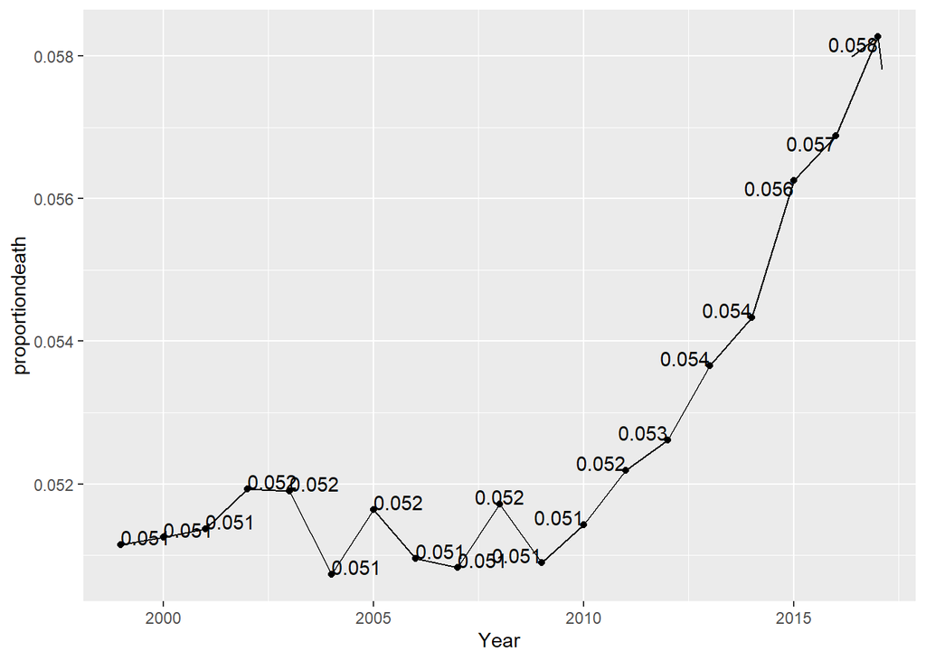

```r
#Death proportion each year Trend
ggplot(yearlydeath, aes(x = Year, y = proportiondeath)) +
  geom_line(arrow = arrow())+
  geom_point()+
  geom_text(aes(label = round(proportiondeath,3)),
            vjust = "inward", hjust = "inward",
            show.legend = FALSE)+
  scale_color_brewer(type = "seq", palette = "Dark2", name = "Country",
                     labels = paste("Country", 1:5))
```

```r
yearlydeath<- USA %>%
    group_by(Year,State,Cause.NameSh) %>%
    summarise(avg_Deaths = mean(Death),
              min_Deaths = min(Death),
              max_Deaths = max(Death),
              total_deaths= sum(Death))%>%
         mutate(proportiondeath = prop.table(total_deaths))%>%
  arrange(desc(Year,State,Cause.NameSh))
kable(head(yearlydeath,5))
```

| Year | State | Cause.NameSh | avg_Deaths | min_Deaths | max_Deaths | total_deaths | proportiondeath |
| --- | --- | --- | --- | --- | --- | --- | --- |
| 2017 | United States | All causes | 2813503 | 2813503 | 2813503 | 2813503 | 0.5747668 |
| 2017 | United States | Alzheimer’s disease | 121404 | 121404 | 121404 | 121404 | 0.0248015 |
| 2017 | United States | Cancer | 599108 | 599108 | 599108 | 599108 | 0.1223910 |
| 2017 | United States | CLRD | 160201 | 160201 | 160201 | 160201 | 0.0327272 |
| 2017 | United States | Diabetes | 83564 | 83564 | 83564 | 83564 | 0.0170712 |

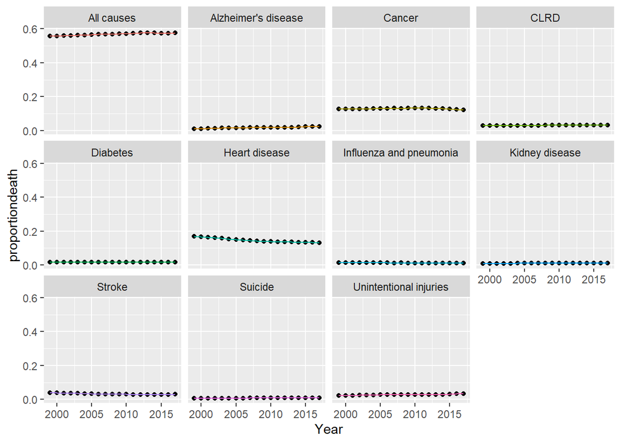

```r
ggplot(yearlydeath, aes(x = Year, y = proportiondeath)) +
  geom_point() +
  geom_line(aes(color = Cause.NameSh)) +
  facet_wrap(~ Cause.NameSh) +
  scale_color_discrete(guide = FALSE)
```

```r
#Deah proportion each year
yearlydeath1<- USA %>%
    group_by(Year) %>%
    summarise(avg_Deaths = mean(Death),
              min_Deaths = min(Death),
              max_Deaths = max(Death),
              total_deaths= sum(Death))%>%
         mutate(proportiondeath = prop.table(total_deaths))%>%
  arrange(desc(Year))
kable(head(yearlydeath1,5))
```

| Year | avg_Deaths | min_Deaths | max_Deaths | total_deaths | proportiondeath |
| --- | --- | --- | --- | --- | --- |
| 2017 | 445003.1 | 47173 | 2813503 | 4895034 | 0.0582679 |
| 2016 | 434397.0 | 44965 | 2744248 | 4778367 | 0.0568791 |
| 2015 | 429604.3 | 44193 | 2712630 | 4725647 | 0.0562516 |
| 2014 | 414984.2 | 42826 | 2626418 | 4564826 | 0.0543372 |
| 2013 | 409754.9 | 41149 | 2596993 | 4507304 | 0.0536525 |

```r
pct_change <- df %>%
   group_by(Cause.NameSh) %>%
  mutate(pct_change = (Death/lead(Death)-1) * 100)

pct_change
```

```
## # A tibble: 10,868 x 7
## # Groups:   Cause.NameSh [11]
##     Year Cause.Name      Cause.NameSh  State   Death Age.Adj.Death.R~ pct_change
##    <int> <chr>           <chr>         <chr>   <dbl>            <dbl>      <dbl>
##  1  2017 Accidents (uni~ Unintentiona~ Unite~ 169936             49.4     6187.
##  2  2017 Accidents (uni~ Unintentiona~ Alaba~   2703             53.8      520.
##  3  2017 Accidents (uni~ Unintentiona~ Alaska    436             63.7      -89.6
##  4  2017 Accidents (uni~ Unintentiona~ Arizo~   4184             56.2      157.
##  5  2017 Accidents (uni~ Unintentiona~ Arkan~   1625             51.8      -88.3
##  6  2017 Accidents (uni~ Unintentiona~ Calif~  13840             33.2      356.
##  7  2017 Accidents (uni~ Unintentiona~ Color~   3037             53.6       46.2
##  8  2017 Accidents (uni~ Unintentiona~ Conne~   2078             53.2      242.
##  9  2017 Accidents (uni~ Unintentiona~ Delaw~    608             61.9       42.4
## 10  2017 Accidents (uni~ Unintentiona~ Distr~    427             61        -96.7
## # ... with 10,858 more rows
```

```r
data_wide1<- pct_change
data_wide2<-spread(data_wide1, State, Death)
kable(head(data_wide2))
```

| Year | Cause.Name | Cause.NameSh | Age.Adj.Death.Rate | pct_change | Alabama | Alaska | Arizona | Arkansas | California | Colorado | Connecticut | Delaware | District of Columbia | Florida | Georgia | Hawaii | Idaho | Illinois | Indiana | Iowa | Kansas | Kentucky | Louisiana | Maine | Maryland | Massachusetts | Michigan | Minnesota | Mississippi | … |
| --- | --- | --- | --- | --- | --- | --- | --- | --- | --- | --- | --- | --- | --- | --- | --- | --- | --- | --- | --- | --- | --- | --- | --- | --- | --- | --- | --- | --- | --- | --- |
| 2017 | Accidents (unintentional injuries) (V01-X59,Y85-Y86) | Unintentional injuries | 49.4 | 6186.94044 | NA | NA | NA | NA | NA | NA | NA | NA | NA | NA | NA | NA | NA | NA | NA | NA | NA | NA | NA | NA | NA | NA | NA | NA | NA | … |
| 2017 | Accidents (unintentional injuries) (V01-X59,Y85-Y86) | Unintentional injuries | 53.8 | 519.95413 | 2703 | NA | NA | NA | NA | NA | NA | NA | NA | NA | NA | NA | NA | NA | NA | NA | NA | NA | NA | NA | NA | NA | NA | NA | NA | … |
| 2017 | Accidents (unintentional injuries) (V01-X59,Y85-Y86) | Unintentional injuries | 63.7 | -89.57935 | NA | 436 | NA | NA | NA | NA | NA | NA | NA | NA | NA | NA | NA | NA | NA | NA | NA | NA | NA | NA | NA | NA | NA | NA | NA | … |
| 2017 | Accidents (unintentional injuries) (V01-X59,Y85-Y86) | Unintentional injuries | 56.2 | 157.47692 | NA | NA | 4184 | NA | NA | NA | NA | NA | NA | NA | NA | NA | NA | NA | NA | NA | NA | NA | NA | NA | NA | NA | NA | NA | NA | … |
| 2017 | Accidents (unintentional injuries) (V01-X59,Y85-Y86) | Unintentional injuries | 51.8 | -88.25867 | NA | NA | NA | 1625 | NA | NA | NA | NA | NA | NA | NA | NA | NA | NA | NA | NA | NA | NA | NA | NA | NA | NA | NA | NA | NA | … |
| 2017 | Accidents (unintentional injuries) (V01-X59,Y85-Y86) | Unintentional injuries | 33.2 | 355.71287 | NA | NA | NA | NA | 13840 | NA | NA | NA | NA | NA | NA | NA | NA | NA | NA | NA | NA | NA | NA | NA | NA | NA | NA | NA | NA | … |

[figure not shown]

```r
ggplot((pct_change), aes(x = Year, y = pct_change)) +
  geom_point() +
  geom_line(aes(color = State)) +
  facet_wrap(~ State, nrow = 1) +
  scale_color_discrete(guide = FALSE)
```

```r
library(shiny)
library(ggplot2)

shinyApp(
  ui = fluidPage(
    sidebarLayout(
      sidebarPanel(
        actionButton("newplot", "New plot")
      ),
      mainPanel(
        plotOutput("plot")
      )
    )
  ),
  server = function(input, output) {
    output$plot <- renderPlot({
      input$newplot
      ggplot(yearlydeath, aes(x = Year, y = proportiondeath)) +
  geom_point() +
  geom_line(aes(color = Cause.NameSh)) +
  facet_wrap(~ Cause.NameSh) +
  scale_color_discrete(guide = FALSE)


    })
  }
)
```

```
## PhantomJS not found. You can install it with webshot::install_phantomjs(). If it is installed, please make sure the phantomjs executable can be found via the PATH variable.
```

Shiny applications not supported in static R Markdown documents

```r
# # /*install.packages('gganimate')*/
# library(gganimate)
#
# # animedf<-USA[!grepl('Cancer',USA$Cause.NameSh),]
# animedf<-USA
# animedf
# #
# # p <- ggplot(
# #   animedf,
# #   aes(Year, Death, group = Cause.NameSh, color = factor(Cause.NameSh))
# #   ) +
# #   geom_line() +
# #   scale_color_viridis_d() +
# #   labs(x = "Year", y = "Deaths") +
# #   theme(legend.position = "top")
# #
# # p + geom_point(aes(group = seq_along(Year))) +
# #   transition_reveal(Year)
#
# # Make a ggplot, but add frame=year: one image per year
# ggplot(animedf, aes(Year, Death, color = factor(Cause.NameSh))
#   ) +
#   geom_point(alpha = 0.7, show.legend = FALSE) +
#   # scale_colour_manual(values = country_colors) +
#   scale_size(range = c(2, 12)) +
#   scale_x_log10() +
#   facet_wrap(~Cause.NameSh) +
#   # Here comes the gganimate specific bits
#   labs(title = 'Year: {frame_time}', x = 'Year', y = 'Death') +
#   transition_time(Year) +
#   ease_aes('linear')
#
# # //anim_save("271-ggplot2-animated-gif-chart-with-gganimate2.gif")
```

```r
# //install.packages("maps")
# install.packages("maps")
# library(maps)
# library(ggplot2)
#
#
# head(usa)
# states <- map_data("state")
# counties <- map_data("county")
# NewYork <- subset(states, region == "new york")
# head(NewYork)
#
# ny_county <- subset(counties, region == "new york")
# head(ny_county)
#
# ggplot() + geom_polygon(data = NewYork, aes(x=long, y = lat, fill = subregion)) +
#   geom_polygon(data = ny_county, aes(x=long, y = lat, group = group), color = "white", fill = NA) +
#   labs(title = "New York State by Counties", x = "longitude", y = "latitude") +
#   coord_fixed(1.3) +
#   theme(panel.background = element_blank())
#
# head(states)
#
# library(tidyverse)
#
# df <- state.x77 %>% as.data.frame() %>% rownames_to_column("state")
# df$State <- tolower(df$state)
#
# df$State
# head(df)
# animedf<-USA
# head(animedf)
# animedf$State <- tolower(animedf$State)
# dataframe_AB = merge(animedf,df,by=NULL)
# head(dataframe_AB)
# str(dataframe_AB)
#
# ggplot(dataframe_AB, aes(map_id = state)) + geom_map(aes(fill = Death), map = states) +
#   expand_limits(x = states$long, y = states$lat) +
#   scale_fill_gradient(low = "white", high = "#FE2EC8") +
#   labs(title = "US Per Capita Income by States, 1974", x = "longitude", y = "latitude",
#        caption = "source: https://www.rdocumentation.org/packages/
#        datasets/versions/3.6.1/topics/state") +
#   coord_fixed(1.3) +
#   theme(panel.background = element_blank())
```

```r
# library(tidyverse)
# library(dplyr)
# library(tidyr)
# library(tibble)
# library(reshape2)
# library(stringr)
# library(readr)
#
#
# library(plotly)
# library(shiny)
# library(rsconnect)
# library(kableExtra)
#
#
#
# ## Importing the data
# Newdf <- read.csv("C:/Users/Banu/Downloads/NCHS_-_Age-adjusted_Death_Rates_for_Selected_Major_Causes_of_Death (1).csv", header= TRUE,na.strings = ".")
#
#
# ## Exploratory data
# head(Newdf)
# dim(Newdf)
# str(Newdf)
# kableExtra::kable(head(Newdf))
#
# summary(Newdf)
```